# hw3_new

- title: "Chapter 4--5: Learning Sheet"
- author: "Chienhua-Hsu"
- date: "4/23/2026"
- output: html_document

# Homework 3 Due 2026/04/23

## 糖尿病預測分析

```r
suppressMessages(install.packages("pROC", quiet = TRUE))
```

```r
diabete <-read.csv("https://gist.githubusercontent.com/chaityacshah/899a95deaf8b1930003ae93944fd17d7/raw/3d35de839da708595a444187e9f13237b51a2cbe/pima-indians-diabetes.csv")
colnames(diabete) <- c("pregnant","glucose", "blood_pressure", "triceps", "serum_insulin", "mass", "pedigree" , "age","diabetes")
str(diabete)
```

```
'data.frame':	768 obs. of  9 variables:
 $ pregnant      : int  6 1 8 1 0 5 3 10 2 8 ...
 $ glucose       : int  148 85 183 89 137 116 78 115 197 125 ...
 $ blood_pressure: int  72 66 64 66 40 74 50 0 70 96 ...
 $ triceps       : int  35 29 0 23 35 0 32 0 45 0 ...
 $ serum_insulin : int  0 0 0 94 168 0 88 0 543 0 ...
 $ mass          : num  33.6 26.6 23.3 28.1 43.1 25.6 31 35.3 30.5 0 ...
 $ pedigree      : num  0.627 0.351 0.672 0.167 2.288 ...
 $ age           : int  50 31 32 21 33 30 26 29 53 54 ...
 $ diabetes      : int  1 0 1 0 1 0 1 0 1 1 ...
```

- Response
  - diabetes: 糖尿病（1:有、0:無）
- Covariates
  - pregnant: 懷孕次數
  - glucose: 血漿葡萄糖濃度
  - blood_pressure: 舒張壓
  - triceps: 三頭肌皮膚褶皺厚度
  - serum_insulin: 血清胰島素
  - mass: BMI
  - pedigree: 糖尿病譜系功能
  - age: 年齡
- Data Analysis
  - Visualization
  - Do model selection for main effect
  - Categorize blood_pressure / serum_insulin variables
  - Does categorized variables fit data better?
  - Consider interaction effect
  - Give me your final model and explain the model

## 1. 變數關係

先用 pairs plot 與 t-test 瞭解各 covariate 與糖尿病的關係。

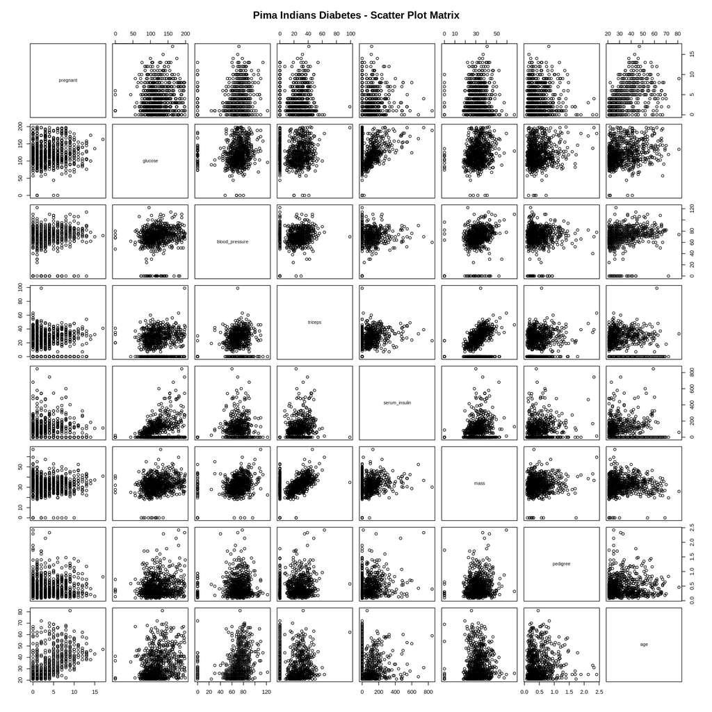

```r
options(repr.plot.width = 14, repr.plot.height = 14)
pairs(diabete[, -9], main = "Pima Indians Diabetes - Scatter Plot Matrix")
options(repr.plot.width = 7, repr.plot.height = 7)
```

```r
## 連續變數與 diabetes 的 t-test
cont_vars <- c("pregnant","glucose","blood_pressure","triceps",
               "serum_insulin","mass","pedigree","age")
for (v in cont_vars) {
  res <- t.test(diabete[[v]] ~ diabete$diabetes)
  cat(sprintf("%-20s p-value = %.4f\n", v, res$p.value))
}
```

```
pregnant             p-value = 0.0000
glucose              p-value = 0.0000
blood_pressure       p-value = 0.0874
triceps              p-value = 0.0494
serum_insulin        p-value = 0.0010
mass                 p-value = 0.0000
pedigree             p-value = 0.0000
age                  p-value = 0.0000
```

**觀察**：

- `glucose`、`mass`、`age`、`pedigree`、`pregnant` 的 p-value 極小，與 diabetes 顯著相關。
- `blood_pressure`、`triceps`、`serum_insulin` 的 p-value 相對較大。
- 注意：`blood_pressure` 與 `serum_insulin` 含有大量 0 值（代表缺失值），可能影響分析。

```r
## 檢查高度相關的 covariates（避免多重共線性）
cor_mat <- cor(diabete[, cont_vars])
round(cor_mat, 2)
```

A matrix: 8 × 8 of type dbl

|  | pregnant | glucose | blood_pressure | triceps | serum_insulin | mass | pedigree | age |
| --- | --- | --- | --- | --- | --- | --- | --- | --- |
| pregnant | 1.00 | 0.13 | 0.14 | -0.08 | -0.07 | 0.02 | -0.03 | 0.54 |
| glucose | 0.13 | 1.00 | 0.15 | 0.06 | 0.33 | 0.22 | 0.14 | 0.26 |
| blood_pressure | 0.14 | 0.15 | 1.00 | 0.21 | 0.09 | 0.28 | 0.04 | 0.24 |
| triceps | -0.08 | 0.06 | 0.21 | 1.00 | 0.44 | 0.39 | 0.18 | -0.11 |
| serum_insulin | -0.07 | 0.33 | 0.09 | 0.44 | 1.00 | 0.20 | 0.19 | -0.04 |
| mass | 0.02 | 0.22 | 0.28 | 0.39 | 0.20 | 1.00 | 0.14 | 0.04 |
| pedigree | -0.03 | 0.14 | 0.04 | 0.18 | 0.19 | 0.14 | 1.00 | 0.03 |
| age | 0.54 | 0.26 | 0.24 | -0.11 | -0.04 | 0.04 | 0.03 | 1.00 |

## 2. 模型選擇

先建立包含所有 covariates 的 Full Model，再用 Backward AIC 做變數選擇。

```r
## Full Model
full.fit <- glm(diabetes ~ pregnant + glucose + blood_pressure + triceps +
                  serum_insulin + mass + pedigree + age,
                family = binomial, data = diabete)
summary(full.fit)
```

```
Call:
glm(formula = diabetes ~ pregnant + glucose + blood_pressure +
    triceps + serum_insulin + mass + pedigree + age, family = binomial,
    data = diabete)

Coefficients:
                 Estimate Std. Error z value Pr(>|z|)
(Intercept)    -8.4046964  0.7166359 -11.728  < 2e-16 ***
pregnant        0.1231823  0.0320776   3.840 0.000123 ***
glucose         0.0351637  0.0037087   9.481  < 2e-16 ***
blood_pressure -0.0132955  0.0052336  -2.540 0.011072 *
triceps         0.0006190  0.0068994   0.090 0.928515
serum_insulin  -0.0011917  0.0009012  -1.322 0.186065
mass            0.0897010  0.0150876   5.945 2.76e-09 ***
pedigree        0.9451797  0.2991475   3.160 0.001580 **
age             0.0148690  0.0093348   1.593 0.111192
---
Signif. codes:  0 ‘***’ 0.001 ‘**’ 0.01 ‘*’ 0.05 ‘.’ 0.1 ‘ ’ 1

(Dispersion parameter for binomial family taken to be 1)

    Null deviance: 993.48  on 767  degrees of freedom
Residual deviance: 723.45  on 759  degrees of freedom
AIC: 741.45

Number of Fisher Scoring iterations: 5
```

```r
## Backward selection by AIC
step.fit <- step(full.fit, direction = "backward")
```

```
Start:  AIC=741.45
diabetes ~ pregnant + glucose + blood_pressure + triceps + serum_insulin +
    mass + pedigree + age

                 Df Deviance    AIC
- triceps         1   723.45 739.45
- serum_insulin   1   725.19 741.19
<none>                723.45 741.45
- age             1   725.97 741.97
- blood_pressure  1   729.99 745.99
- pedigree        1   733.78 749.78
- pregnant        1   738.68 754.68
- mass            1   764.22 780.22
- glucose         1   838.37 854.37

Step:  AIC=739.45
diabetes ~ pregnant + glucose + blood_pressure + serum_insulin +
    mass + pedigree + age

                 Df Deviance    AIC
<none>                723.45 739.45
- serum_insulin   1   725.46 739.46
- age             1   725.97 739.97
- blood_pressure  1   730.13 744.13
- pedigree        1   733.92 747.92
- pregnant        1   738.69 752.69
- mass            1   768.77 782.77
- glucose         1   840.87 854.87
```

```r
## Parsimonious Model（AIC 選出的結果）
summary(step.fit)
```

```
Call:
glm(formula = diabetes ~ pregnant + glucose + blood_pressure +
    serum_insulin + mass + pedigree + age, family = binomial,
    data = diabete)

Coefficients:
                 Estimate Std. Error z value Pr(>|z|)
(Intercept)    -8.4051362  0.7167033 -11.727  < 2e-16 ***
pregnant        0.1231724  0.0320688   3.841 0.000123 ***
glucose         0.0351123  0.0036625   9.587  < 2e-16 ***
blood_pressure -0.0132136  0.0051537  -2.564 0.010350 *
serum_insulin  -0.0011570  0.0008142  -1.421 0.155275
mass            0.0900886  0.0144619   6.229 4.68e-10 ***
pedigree        0.9475954  0.2980063   3.180 0.001474 **
age             0.0147888  0.0092897   1.592 0.111393
---
Signif. codes:  0 ‘***’ 0.001 ‘**’ 0.01 ‘*’ 0.05 ‘.’ 0.1 ‘ ’ 1

(Dispersion parameter for binomial family taken to be 1)

    Null deviance: 993.48  on 767  degrees of freedom
Residual deviance: 723.45  on 760  degrees of freedom
AIC: 739.45

Number of Fisher Scoring iterations: 5
```

**模型選擇結論**：

- Backward AIC 保留 `pregnant`、`glucose`、`blood_pressure`、`serum_insulin`、`mass`、`pedigree`、`age`（AIC = 739.45）。
- 僅 `triceps` 被剔除（移除後 AIC 從 741.45 降至 739.45）。
- `serum_insulin` 雖 p-value 不顯著（0.155），但移除後 AIC 幾乎不變（739.46 vs 739.45），故保留。
- `blood_pressure` 在單變量 t-test 中不顯著（p = 0.087），但在多變量模型中 p = 0.010，應保留。

## 3. 將 `blood_pressure` 與 `serum_insulin` 類別化

依照臨床閾值切割：

[output not shown]

```r
## 類別化 blood_pressure（舒張壓）
diabete$bp_cat <- cut(diabete$blood_pressure,
                      breaks = c(-Inf, 60, 80, Inf),
                      labels = c("low", "normal", "high"),
                      include.lowest = TRUE)

## 類別化 serum_insulin
diabete$insulin_cat <- cut(diabete$serum_insulin,
                           breaks = c(-Inf, 100, 200, Inf),
                           labels = c("low", "normal", "high"),
                           include.lowest = TRUE)

table(diabete$bp_cat)
table(diabete$insulin_cat)
```

```
   low normal   high
   158    445    165
```

```
   low normal   high
   525    158     85
```

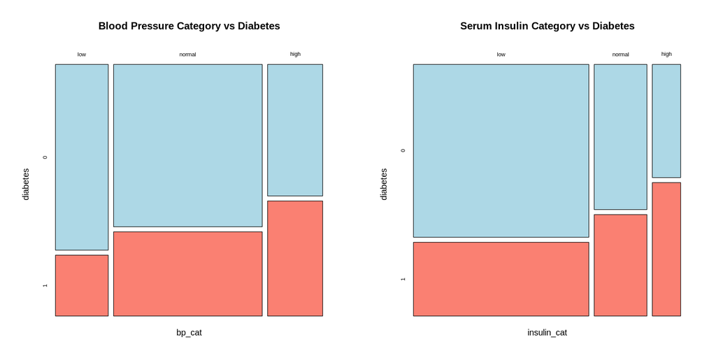

```r
options(repr.plot.width = 14, repr.plot.height = 7)
par(mfrow = c(1, 2), mar = c(4, 4, 5, 2))
mosaicplot(~ bp_cat + diabetes, data = diabete,
           main = "Blood Pressure Category vs Diabetes",
           color = c("lightblue", "salmon"))
mosaicplot(~ insulin_cat + diabetes, data = diabete,
           main = "Serum Insulin Category vs Diabetes",
           color = c("lightblue", "salmon"))
par(mfrow = c(1, 1), mar = c(5, 4, 4, 2))
options(repr.plot.width = 7, repr.plot.height = 7)
```

```r
## Chi-square test
chisq.test(table(diabete$diabetes, diabete$bp_cat))
chisq.test(table(diabete$diabetes, diabete$insulin_cat))
```

```
	Pearson's Chi-squared test

data:  table(diabete$diabetes, diabete$bp_cat)
X-squared = 17.423, df = 2, p-value = 0.0001647
```

```
	Pearson's Chi-squared test

data:  table(diabete$diabetes, diabete$insulin_cat)
X-squared = 22.291, df = 2, p-value = 1.444e-05
```

**觀察**：

- `bp_cat` vs diabetes：χ² = 17.42，p = 0.00016（顯著）。
- `insulin_cat` vs diabetes：χ² = 22.29，p = 0.0000144（顯著）。
- 兩個類別化變數皆與 diabetes 有顯著關聯，值得進一步放入模型比較。

## 4. 類別化變數是否讓模型更好？

以 AIC 比較「連續型」vs「類別型」blood_pressure/serum_insulin 的模型。

```r
## 以 step.fit 選出的 parsimonious model 為基礎加入類別化變數
cat.fit <- glm(diabetes ~ pregnant + glucose + bp_cat + insulin_cat +
                 mass + pedigree + age,
               family = binomial, data = diabete)
summary(cat.fit)
```

```
Call:
glm(formula = diabetes ~ pregnant + glucose + bp_cat + insulin_cat +
    mass + pedigree + age, family = binomial, data = diabete)

Coefficients:
                   Estimate Std. Error z value Pr(>|z|)
(Intercept)       -8.943688   0.736905 -12.137  < 2e-16 ***
pregnant           0.120690   0.032030   3.768 0.000165 ***
glucose            0.034499   0.003657   9.433  < 2e-16 ***
bp_catnormal      -0.078538   0.254027  -0.309 0.757190
bp_cathigh        -0.238054   0.304912  -0.781 0.434960
insulin_catnormal -0.014240   0.225454  -0.063 0.949639
insulin_cathigh   -0.360228   0.302562  -1.191 0.233814
mass               0.085006   0.014574   5.833 5.45e-09 ***
pedigree           0.924379   0.296908   3.113 0.001850 **
age                0.012739   0.009342   1.364 0.172667
---
Signif. codes:  0 ‘***’ 0.001 ‘**’ 0.01 ‘*’ 0.05 ‘.’ 0.1 ‘ ’ 1

(Dispersion parameter for binomial family taken to be 1)

    Null deviance: 993.48  on 767  degrees of freedom
Residual deviance: 730.24  on 758  degrees of freedom
AIC: 750.24

Number of Fisher Scoring iterations: 5
```

```r
## AIC 比較
cat("Continuous model (step) AIC:", AIC(step.fit), "\n")
cat("Categorized bp/insulin AIC:  ", AIC(cat.fit), "\n")
```

[output not shown]

**結論**：

- 連續型模型（step.fit）AIC = **739.45**；類別化模型 AIC = **750.24**，差距約 11。
- **連續型模型明顯優於類別化模型**，應保留連續型 `blood_pressure` 與 `serum_insulin`。
- 類別化後各組係數均不顯著（p > 0.23），表示類別化無法有效區分不同風險層級。

## 5. 交互作用

考慮主要代謝風險因素之間的交互作用：

- `glucose × mass`：血糖與 BMI 同為代謝症候群指標
- `glucose × age`：血糖效應是否因年齡而異

```r
## Interaction: glucose × mass
int.fit1 <- glm(diabetes ~ pregnant + glucose * mass + pedigree + age,
                family = binomial, data = diabete)
summary(int.fit1)
cat("AIC (glucose × mass):", AIC(int.fit1), "\n")
```

```
Call:
glm(formula = diabetes ~ pregnant + glucose * mass + pedigree +
    age, family = binomial, data = diabete)

Coefficients:
               Estimate Std. Error z value Pr(>|z|)
(Intercept)  -1.123e+01  2.340e+00  -4.798 1.61e-06 ***
pregnant      1.207e-01  3.170e-02   3.809  0.00014 ***
glucose       5.355e-02  1.828e-02   2.929  0.00340 **
mass          1.559e-01  6.759e-02   2.306  0.02109 *
pedigree      9.142e-01  2.922e-01   3.128  0.00176 **
age           1.084e-02  9.180e-03   1.181  0.23751
glucose:mass -6.086e-04  5.250e-04  -1.159  0.24636
---
Signif. codes:  0 ‘***’ 0.001 ‘**’ 0.01 ‘*’ 0.05 ‘.’ 0.1 ‘ ’ 1

(Dispersion parameter for binomial family taken to be 1)

    Null deviance: 993.48  on 767  degrees of freedom
Residual deviance: 731.17  on 761  degrees of freedom
AIC: 745.17

Number of Fisher Scoring iterations: 5
```

```
AIC (glucose × mass): 745.1732
```

```r
## Interaction: glucose × age
int.fit2 <- glm(diabetes ~ pregnant + glucose * age + mass + pedigree,
                family = binomial, data = diabete)
summary(int.fit2)
cat("AIC (glucose × age):", AIC(int.fit2), "\n")
```

```
Call:
glm(formula = diabetes ~ pregnant + glucose * age + mass + pedigree,
    family = binomial, data = diabete)

Coefficients:
              Estimate Std. Error z value Pr(>|z|)
(Intercept) -1.083e+01  1.432e+00  -7.564 3.92e-14 ***
pregnant     1.120e-01  3.144e-02   3.564 0.000366 ***
glucose      5.035e-02  1.062e-02   4.740 2.14e-06 ***
age          7.611e-02  3.716e-02   2.048 0.040565 *
mass         7.710e-02  1.389e-02   5.549 2.87e-08 ***
pedigree     8.665e-01  2.939e-01   2.948 0.003198 **
glucose:age -4.833e-04  2.727e-04  -1.773 0.076305 .
---
Signif. codes:  0 ‘***’ 0.001 ‘**’ 0.01 ‘*’ 0.05 ‘.’ 0.1 ‘ ’ 1

(Dispersion parameter for binomial family taken to be 1)

    Null deviance: 993.48  on 767  degrees of freedom
Residual deviance: 729.46  on 761  degrees of freedom
AIC: 743.46

Number of Fisher Scoring iterations: 5
```

```
AIC (glucose × age): 743.4632
```

```r
## 綜合 AIC 比較
cat("Parsimonious (no interaction) AIC:", AIC(step.fit), "\n")
cat("Interaction glucose×mass AIC:     ", AIC(int.fit1), "\n")
cat("Interaction glucose×age  AIC:     ", AIC(int.fit2), "\n")
```

[output not shown]

**結論**：

- 無交互作用模型（step.fit）AIC = **739.45**（最低）。
- `glucose × mass` AIC = 745.17（+5.72），交互作用項 p = 0.246，**不顯著**。
- `glucose × age` AIC = 743.46（+4.01），交互作用項 p = 0.076，**邊際顯著但 AIC 反而上升**。
- 兩個交互作用模型的 AIC 均高於無交互作用模型，依 parsimony 原則**不加入交互作用**。

## 6. 最終模型與解釋

根據上述分析，選擇 AIC 最小且解釋性最佳的模型為最終模型。

```r
## 最終模型（以 step 選出的 parsimonious 模型為基礎，視交互作用 AIC 結果調整）
final.fit <- step.fit   # 若交互作用顯著改善，改為 int.fit1 或 int.fit2
summary(final.fit)
```

```
Call:
glm(formula = diabetes ~ pregnant + glucose + blood_pressure +
    serum_insulin + mass + pedigree + age, family = binomial,
    data = diabete)

Coefficients:
                 Estimate Std. Error z value Pr(>|z|)
(Intercept)    -8.4051362  0.7167033 -11.727  < 2e-16 ***
pregnant        0.1231724  0.0320688   3.841 0.000123 ***
glucose         0.0351123  0.0036625   9.587  < 2e-16 ***
blood_pressure -0.0132136  0.0051537  -2.564 0.010350 *
serum_insulin  -0.0011570  0.0008142  -1.421 0.155275
mass            0.0900886  0.0144619   6.229 4.68e-10 ***
pedigree        0.9475954  0.2980063   3.180 0.001474 **
age             0.0147888  0.0092897   1.592 0.111393
---
Signif. codes:  0 ‘***’ 0.001 ‘**’ 0.01 ‘*’ 0.05 ‘.’ 0.1 ‘ ’ 1

(Dispersion parameter for binomial family taken to be 1)

    Null deviance: 993.48  on 767  degrees of freedom
Residual deviance: 723.45  on 760  degrees of freedom
AIC: 739.45

Number of Fisher Scoring iterations: 5
```

```
AUC: 0.8395746
```

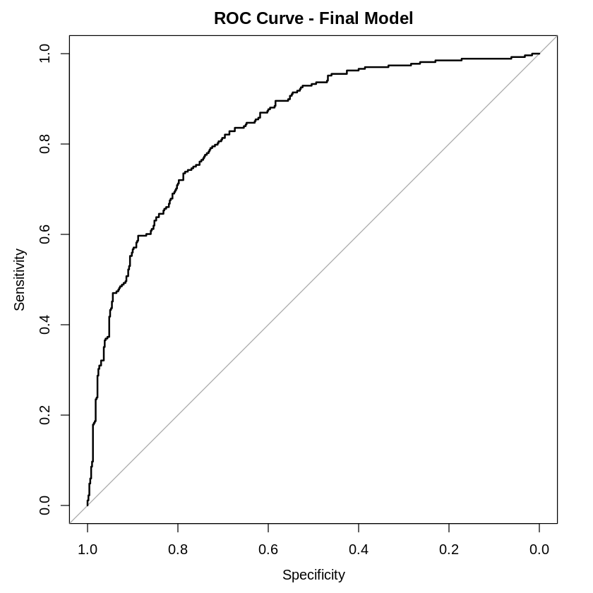

```r
## ROC curve 與 AUC
suppressMessages(suppressWarnings(library(pROC)))
pred_prob <- predict(final.fit, type = "response")
roc_final <- roc(diabete$diabetes, pred_prob, quiet = TRUE)
cat("AUC:", auc(roc_final), "\n")
plot(roc_final, main = "ROC Curve - Final Model")
```

```r
## Odds Ratio 與 95% CI
print("=== Coefficients ===")
print(round(coef(final.fit), 4))

print("=== Odds Ratios ===")
print(round(exp(coef(final.fit)), 4))

print("=== 95% CI for Odds Ratios ===")
suppressMessages(print(round(exp(confint(final.fit)), 4)))
```

[output not shown]

### 模型解釋

$$ \log\frac{\pi}{1-\pi} = -8.405 + 0.123\,\text{pregnant} + 0.0351\,\text{glucose} - 0.0132\,\text{blood\_pressure} - 0.00116\,\text{serum\_insulin} + 0.0901\,\text{mass} + 0.9476\,\text{pedigree} + 0.0148\,\text{age} $$

**AUC = 0.840**，顯示模型具有良好的辨別力。

**各變數 Odds Ratio 解釋**（其他條件不變）：

| 變數 | OR | 95% CI | 解釋 |
| --- | --- | --- | --- |
| `glucose` | **1.036** | (1.029, 1.043) | 血糖每升高 1 mg/dL，罹糖尿病的勝算為原來的 **1.036 倍**；影響最顯著 (p < 2e-16) |
| `mass` (BMI) | **1.094** | (1.064, 1.127) | BMI 每增加 1 kg/m²，勝算為原來的 **1.094 倍** |
| `pedigree` | **2.580** | (1.448, 4.658) | 譜系功能每增加 1 單位，勝算約為原來的 **2.58 倍**，反映強烈的遺傳風險 |
| `pregnant` | **1.131** | (1.063, 1.205) | 懷孕次數每增加 1 次，勝算為原來的 **1.131 倍** |
| `age` | **1.015** | (0.997, 1.034) | 年齡每增加 1 歲，勝算為原來的 1.015 倍（95% CI 含 1，不顯著） |
| `blood_pressure` | **0.987** | (0.977, 0.997) | 舒張壓每升高 1 mmHg，勝算反而略降；控制其他因素後仍顯著 (p = 0.010) |
| `serum_insulin` | **0.999** | (0.997, 1.000) | 效應極微且不顯著 (p = 0.155)，但移除後 AIC 幾乎不變，故由 AIC 選擇保留 |

**總結**：  
`glucose` 為最強的糖尿病預測因子，其次為 `pedigree`（遺傳）與 `mass`（肥胖）。`blood_pressure` 在單變量分析中不顯著，但在多變量模型中有保護性效應（高血壓患者可能已接受藥物治療）。最終模型 AUC = 0.840，在解釋性與預測力之間取得良好平衡。